# Classification

## STAT318/462 Lab3

### Logistic Regression, LDA, QDA and KNN

In this lab you will work through Section 4.6 of the course textbook, An *Introduction to Statistical Learning* (there is a link to this textbook on the Learn page). The R code from Section 4.6 is given below.

## The Stock Market Data

The first thing to do is to load the necessary package and briefly explore the data set called **Smarket**

```r
library(ISLR)
names(Smarket)
```

```
[1] "Year"      "Lag1"      "Lag2"      "Lag3"      "Lag4"      "Lag5"      "Volume"    "Today"     "Direction"
```

```r
dim(Smarket)
```

```
[1] 1250    9
```

The data set has 1250 rows (observations) and 9 columns (variables)

```r
summary(Smarket)
```

```
      Year           Lag1                Lag2                Lag3                Lag4                Lag5              Volume           Today           Direction
 Min.   :2001   Min.   :-4.922000   Min.   :-4.922000   Min.   :-4.922000   Min.   :-4.922000   Min.   :-4.92200   Min.   :0.3561   Min.   :-4.922000   Down:602
 1st Qu.:2002   1st Qu.:-0.639500   1st Qu.:-0.639500   1st Qu.:-0.640000   1st Qu.:-0.640000   1st Qu.:-0.64000   1st Qu.:1.2574   1st Qu.:-0.639500   Up  :648
 Median :2003   Median : 0.039000   Median : 0.039000   Median : 0.038500   Median : 0.038500   Median : 0.03850   Median :1.4229   Median : 0.038500
 Mean   :2003   Mean   : 0.003834   Mean   : 0.003919   Mean   : 0.001716   Mean   : 0.001636   Mean   : 0.00561   Mean   :1.4783   Mean   : 0.003138
 3rd Qu.:2004   3rd Qu.: 0.596750   3rd Qu.: 0.596750   3rd Qu.: 0.596750   3rd Qu.: 0.596750   3rd Qu.: 0.59700   3rd Qu.:1.6417   3rd Qu.: 0.596750
 Max.   :2005   Max.   : 5.733000   Max.   : 5.733000   Max.   : 5.733000   Max.   : 5.733000   Max.   : 5.73300   Max.   :3.1525   Max.   : 5.733000
```

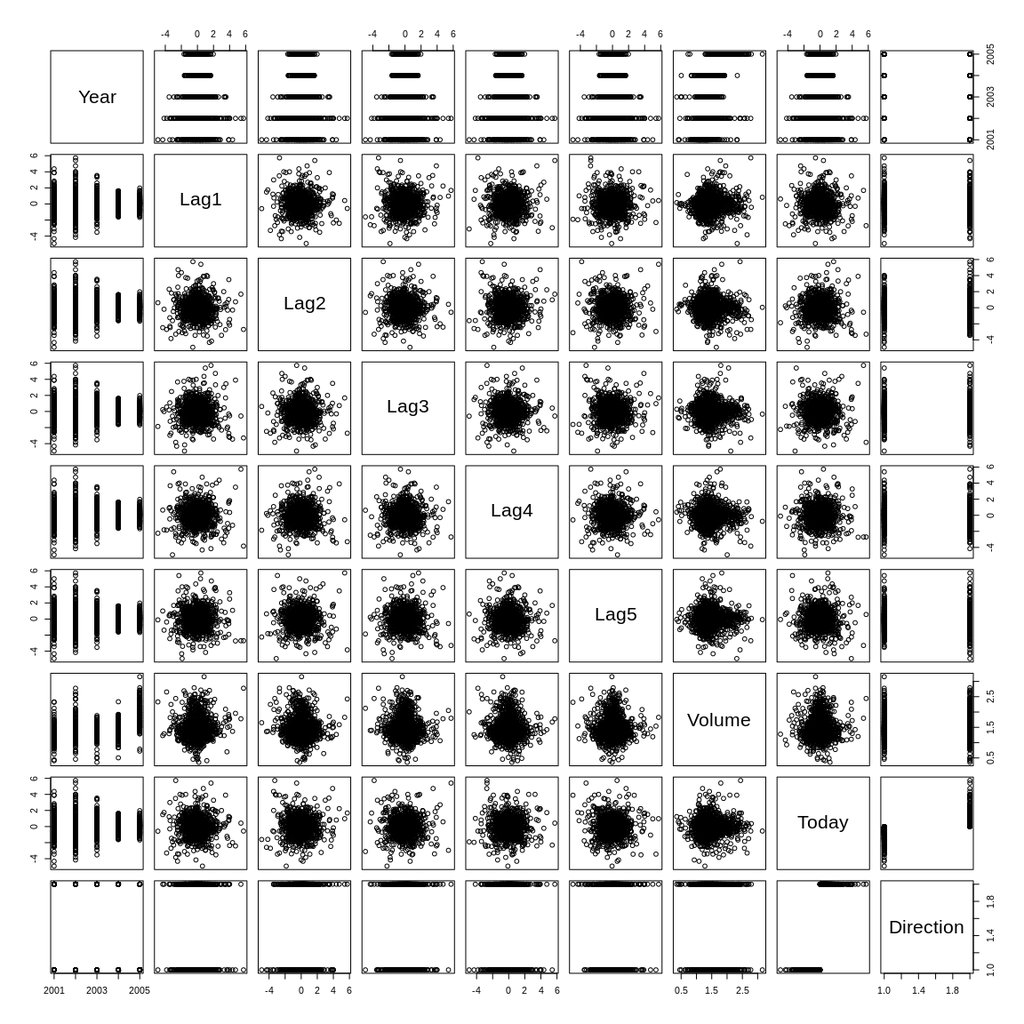

```r
pairs(Smarket)
```

The next line of code will fail. Why?

```r
cor(Smarket)
```

> Error in cor(Smarket) : ‘x’ must be numeric

What has happened here?  
The `cor` function only works on numeric variables. The last column is a factor. We need to repeat this with the last column excluded. We can exclude a column by using a negative column number. There are (as usual) many other ways of doing this.

```r
cor(Smarket[,-9])
```

```
             Year         Lag1         Lag2         Lag3         Lag4         Lag5      Volume        Today
Year   1.00000000  0.029699649  0.030596422  0.033194581  0.035688718  0.029787995  0.53900647  0.030095229
Lag1   0.02969965  1.000000000 -0.026294328 -0.010803402 -0.002985911 -0.005674606  0.04090991 -0.026155045
Lag2   0.03059642 -0.026294328  1.000000000 -0.025896670 -0.010853533 -0.003557949 -0.04338321 -0.010250033
Lag3   0.03319458 -0.010803402 -0.025896670  1.000000000 -0.024051036 -0.018808338 -0.04182369 -0.002447647
Lag4   0.03568872 -0.002985911 -0.010853533 -0.024051036  1.000000000 -0.027083641 -0.04841425 -0.006899527
Lag5   0.02978799 -0.005674606 -0.003557949 -0.018808338 -0.027083641  1.000000000 -0.02200231 -0.034860083
Volume 0.53900647  0.040909908 -0.043383215 -0.041823686 -0.048414246 -0.022002315  1.00000000  0.014591823
Today  0.03009523 -0.026155045 -0.010250033 -0.002447647 -0.006899527 -0.034860083  0.01459182  1.000000000
```

That is better.

Let’s attach the data set so that we can use its columns as if they are R variables. This will apply for the rest of this session. We can plot the **Volume** variable of the **Smarket** dataset.

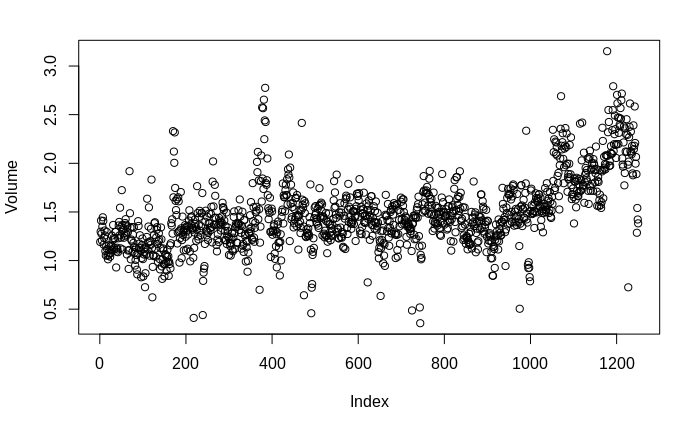

```r
attach(Smarket)
plot(Volume)
```

How would you turn this plot into a line graph? Research this yourself.

## Logistic Regression - GLM

Logistic regression is a special case of **Generalised Linear Modelling** (GLM) using the *Binomial* distribution family.

The parameters to GLM are

1. the model formula
2. the data set
3. the distribution family

Note that we do not **need** to pass the data set because the **attach** has dealt with that.

```r
glm.fit=glm(Direction~Lag1+Lag2+Lag3+Lag4+Lag5+Volume, data=Smarket, family=binomial)
summary(glm.fit)
```

```
Call:
glm(formula = Direction ~ Lag1 + Lag2 + Lag3 + Lag4 + Lag5 +
    Volume, family = binomial, data = Smarket)

Deviance Residuals:
   Min      1Q  Median      3Q     Max
-1.446  -1.203   1.065   1.145   1.326

Coefficients:
             Estimate Std. Error z value Pr(>|z|)
(Intercept) -0.126000   0.240736  -0.523    0.601
Lag1        -0.073074   0.050167  -1.457    0.145
Lag2        -0.042301   0.050086  -0.845    0.398
Lag3         0.011085   0.049939   0.222    0.824
Lag4         0.009359   0.049974   0.187    0.851
Lag5         0.010313   0.049511   0.208    0.835
Volume       0.135441   0.158360   0.855    0.392

(Dispersion parameter for binomial family taken to be 1)

    Null deviance: 1731.2  on 1249  degrees of freedom
Residual deviance: 1727.6  on 1243  degrees of freedom
AIC: 1741.6

Number of Fisher Scoring iterations: 3
```

The summary gives a lot of useful information.

The glm “model” resides in the variable called *glm.fit*. This will be some kind of complex data list that holds everything that is known about the model. This information can be hard to get at. R has a number of convenient functions for extracting the typical kinds of information that we frequently need. The **coef()** is one of these.

```r
coef(glm.fit)
```

```
 (Intercept)         Lag1         Lag2         Lag3         Lag4         Lag5       Volume
-0.126000257 -0.073073746 -0.042301344  0.011085108  0.009358938  0.010313068  0.135440659
```

Despite its name the **summary** function does not intrinsically print anything. It only prints because we are not assigning it to a variable. If we did assign it to a variable and “looked inside” that variable we would see it is made up of lists of lists. We can access these lists if we know what they are called. As it happens the summary output has a list named *coef*. The $ character tells R that we are interested in a named thing inside of a variable.

```r
summary(glm.fit)$coef
```

```
                Estimate Std. Error    z value  Pr(>|z|)
(Intercept) -0.126000257 0.24073574 -0.5233966 0.6006983
Lag1        -0.073073746 0.05016739 -1.4565986 0.1452272
Lag2        -0.042301344 0.05008605 -0.8445733 0.3983491
Lag3         0.011085108 0.04993854  0.2219750 0.8243333
Lag4         0.009358938 0.04997413  0.1872757 0.8514445
Lag5         0.010313068 0.04951146  0.2082966 0.8349974
Volume       0.135440659 0.15835970  0.8552723 0.3924004
```

Notice how *summary(glm.fit)$coef* has additional information to *coef(glm.fit)*

We can restrict ourselves to the fourth column. Bear in mind that the first column (of labels) is not really counted as a column. Likewise the first row (of labels) is not really a row.

```r
summary(glm.fit)$coef[,4]
```

```
(Intercept)        Lag1        Lag2        Lag3        Lag4        Lag5      Volume
  0.6006983   0.1452272   0.3983491   0.8243333   0.8514445   0.8349974   0.3924004
```

Notice how R lays this out sideways to save space. Do not be fooled into thinking this means it is a set of 7 vectors of length 1. It is a single vector of length 7.

Suppose you want to use the model to predict the target variable **Direction**. Also let’s suppose we want the *probability* of this prediction (since it is a categorical prediction). This is the effect of *type=“response”* in the code below. By default the training data will be re-used since we are not specifying any specific data to predict with.

```r
glm.probs=predict(glm.fit, type="response")
glm.probs[1:10]
```

```
        1         2         3         4         5         6         7         8         9        10
0.5070841 0.4814679 0.4811388 0.5152224 0.5107812 0.5069565 0.4926509 0.5092292 0.5176135 0.4888378
```

Let’s remind ourselves how **Direction** is being portrayed in the data.

```r
contrasts(Direction)
```

```
     Up
Down  0
Up    1
```

So probabilities < 0.5 are closer to 0 (Down) than 1 (Up)

Let’s create a vector that contains 1250 “Down” entries. Then replace the value with “Up” if the prediction probability is > 0.5

```r
glm.pred=rep("Down",1250)
glm.pred[glm.probs>.5]="Up"
```

Did you understand that 2nd line? Rather than assigning to all elements of the vector *glm.pred* we will only replace the values that positionally statisfy the rule *glm.prob > 0.5*.

Rather than listing 1250 up/down values, we shall calculate the “confusion matrix”" using **table()**. In this case we shall create a pair of vectors. The first representing the prediction, the second representing the actual.

```r
table(glm.pred,Direction)
```

```
        Direction
glm.pred Down  Up
    Down  145 141
    Up    457 507
```

How accurate (as a ratio between 0 and 1) have we been? Accuracy is the leading diagonal (summed) divided by the total of all the cells.

```r
(507+145)/1250
```

```
[1] 0.5216
```

Look at this short-cut way of achieving the same thing.

```r
mean(glm.pred==Direction)
```

```
[1] 0.5216
```

This works because logical values can be viewed as 0 for False, and 1 for True. The mean of these zero and ones amounts to the same thing.

## Dividing up a data set

Let’s create a logical vector that is True when the year is prior to 2005. We can use this new vector to choose rows from our data set.

```r
train=(Year<2005)
Smarket.2005=Smarket[!train,]
dim(Smarket.2005)
```

```
[1] 252   9
```

We can do the same with a vector

```r
Direction.2005=Direction[!train]
```

Suppose we create a more flexible model (using all the predictors) BUT this time we restrict its training to data prior to 2005. We can use the *subset* parameter. We can repeat the analysis steps we used earlier.

```r
glm.fit=glm(Direction~Lag1+Lag2+Lag3+Lag4+Lag5+Volume,data=Smarket,family=binomial,subset=train)
glm.probs=predict(glm.fit,Smarket.2005,type="response")
glm.pred=rep("Down",252)
glm.pred[glm.probs>.5]="Up"
table(glm.pred,Direction.2005)
```

```
        Direction.2005
glm.pred Down Up
    Down   77 97
    Up     34 44
```

We need to turn this confusion matrix into a single accuracy value.

```r
mean(glm.pred==Direction.2005)
```

```
[1] 0.4801587
```

This suggests that the model is 48% accurate on unseen data (i.e. rows from 2005 that were NOT used in the training)

```r
mean(glm.pred!=Direction.2005)
```

```
[1] 0.5198413
```

This suggests that the model is wrong 52% of the time on unseen data.

Let’s repeat this whole process with a slightly less flexible model. We will model using predictors Lag1 & Lag2.

```r
glm.fit=glm(Direction~Lag1+Lag2,data=Smarket,family=binomial,subset=train)
glm.probs=predict(glm.fit,Smarket.2005,type="response")
glm.pred=rep("Down",252)
glm.pred[glm.probs>.5]="Up"
table(glm.pred,Direction.2005)
```

```
        Direction.2005
glm.pred Down  Up
    Down   35  35
    Up     76 106
```

Calculate the Accuracy on unseen data

```r
mean(glm.pred==Direction.2005)
```

```
[1] 0.5595238
```

Calculate the proportion of time we predict “Up” correctly. Note that this is a different calculation to *Accuracy*

```r
106/(106+76)
```

```
[1] 0.5824176
```

Let’s create two new observations and predict the outcome

```r
predict(glm.fit,newdata=data.frame(Lag1=c(1.2,1.5),Lag2=c(1.1,-0.8)), type="response")
```

```
        1         2
0.4791462 0.4960939
```

This predicts “Down” both times.

## Linear Discriminant Analysis - LDA

We are going to use the *MASS* library’s **lda()** function to model *Direction* using *Lag1* & *Lag2*

```r
library(MASS)
lda.fit=lda(Direction~Lag1+Lag2, data=Smarket, subset=train)
lda.fit
```

```
Call:
lda(Direction ~ Lag1 + Lag2, data = Smarket, subset = train)

Prior probabilities of groups:
    Down       Up
0.491984 0.508016

Group means:
            Lag1        Lag2
Down  0.04279022  0.03389409
Up   -0.03954635 -0.03132544

Coefficients of linear discriminants:
            LD1
Lag1 -0.6420190
Lag2 -0.5135293
```

Notice that **lda** produces different output to **glm()**

We can plot the behaviour of this model;

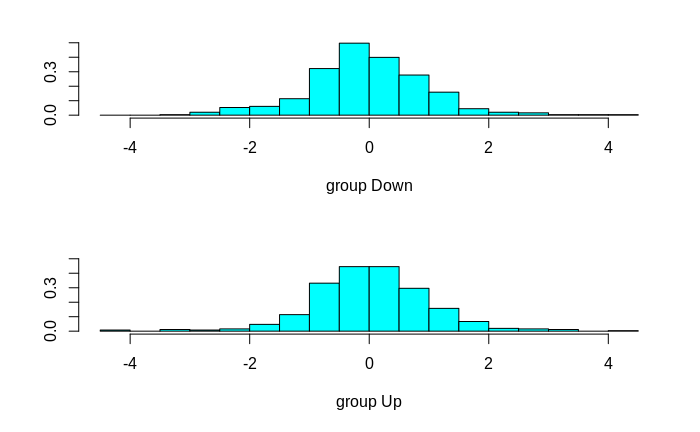

```r
plot(lda.fit)
```

Let’s use our train/test division of the data set and generate an lda model on the train data. We can examine what named things are inside the model.

```r
lda.pred=predict(lda.fit, Smarket.2005)
names(lda.pred)
```

```
[1] "class"     "posterior" "x"
```

Let’s look at the “class” aspect of the model:

```r
lda.class=lda.pred$class
table(lda.class,Direction.2005)
```

```
         Direction.2005
lda.class Down  Up
     Down   35  35
     Up     76 106
```

Calculate accuracy:

```r
mean(lda.class==Direction.2005)
```

```
[1] 0.5595238
```

Applying a 50% threshold to the posterior probabilities allows us to recreate the predictions contained in *lda.pred$class*.

```r
sum(lda.pred$posterior[,1]>=.5)
```

```
[1] 70
```

```r
sum(lda.pred$posterior[,1]<.5)
```

```
[1] 182
```

The posterior probablilities relate to the classifications using a threshold of 0.5

```r
lda.pred$posterior[1:20,1]
```

```
      999      1000      1001      1002      1003      1004      1005      1006      1007      1008      1009      1010      1011      1012      1013      1014      1015
0.4901792 0.4792185 0.4668185 0.4740011 0.4927877 0.4938562 0.4951016 0.4872861 0.4907013 0.4844026 0.4906963 0.5119988 0.4895152 0.4706761 0.4744593 0.4799583 0.4935775
     1016      1017      1018
0.5030894 0.4978806 0.4886331
```

```r
lda.class[1:20]
```

```
 [1] Up   Up   Up   Up   Up   Up   Up   Up   Up   Up   Up   Down Up   Up   Up   Up   Up   Down Up   Up
Levels: Down Up
```

Note the posterior probabilities are that the market will drop.

We can utilise a different threshold; say 0.9

```r
sum(lda.pred$posterior[,1]>.9)
```

```
[1] 0
```

There were no occasions in all of 2005 when that threshold was met.

## Quadratic Discriminant Analysis - QDA

We shall utilise the **qda()** model (also) from the *MASS* library.

```r
qda.fit=qda(Direction~Lag1+Lag2,data=Smarket,subset=train)
qda.fit
```

```
Call:
qda(Direction ~ Lag1 + Lag2, data = Smarket, subset = train)

Prior probabilities of groups:
    Down       Up
0.491984 0.508016

Group means:
            Lag1        Lag2
Down  0.04279022  0.03389409
Up   -0.03954635 -0.03132544
```

```r
qda.class=predict(qda.fit,Smarket.2005)$class
table(qda.class,Direction.2005)
```

```
         Direction.2005
qda.class Down  Up
     Down   30  20
     Up     81 121
```

```r
mean(qda.class==Direction.2005)
```

```
[1] 0.5992063
```

The accuracy of the model on unseen data was 60%. This is looking better.

## K-Nearest Neighbors - KNN

We shall utilise the **knn()** model from the *class* library.  
We shall reorganise the data formally into a test data set and a train data set.

```r
library(class)
train.X=cbind(Lag1,Lag2)[train,]
test.X=cbind(Lag1,Lag2)[!train,]
train.Direction=Direction[train]
```

Next, let’s train the knn (using k=1) - we will make this reproducable by setting the random seed

```r
set.seed(1)
knn.pred=knn(train.X,test.X,train.Direction,k=1)
```

```r
table(knn.pred,Direction.2005)
```

```
        Direction.2005
knn.pred Down Up
    Down   43 58
    Up     68 83
```

```r
(83+43)/252
```

```
[1] 0.5
```

The accuracy is a mere 50%

Let’s change a meta parameter of the algorithm (k=3 this time) and try again.

```r
knn.pred=knn(train.X,test.X,train.Direction,k=3)
table(knn.pred,Direction.2005)
```

```
        Direction.2005
knn.pred Down Up
    Down   48 54
    Up     63 87
```

```r
mean(knn.pred==Direction.2005)
```

```
[1] 0.5357143
```

Now we have an accuracy of 54%. Maybe further tweaking of the *k* parameter will produce an even better result.

## An Application to Caravan Insurance Data

```r
dim(Caravan)
```

```
[1] 5822   86
```

```r
attach(Caravan)
summary(Purchase)
```

```
  No  Yes
5474  348
```

The values of the *Purchase* variable of *Caravan* data set are far from balanced.

The proportion of *Yes* is

```r
348/5822
```

```
[1] 0.05977327
```

That is 6%. If we did no modelling except to always predict “No” we would be right 94% of the time!

Another problem with this data set is that the predictors have wildly different scales. In this situation it is good practice to subtract the column means and to then divide by the standard deviation. There is an R function for doing this: **scale()**.  
Since column 86 is a factor we shall exclude it from the scaling (as it has no meaning for factors). We can conveniently exclude a column by making its index negative

```r
standardized.X=scale(Caravan[,-86])
```

We shall see the effect this has on the variance of columns before and after the scaling

```r
var(Caravan[,1])
```

```
[1] 165.0378
```

```r
var(Caravan[,2])
```

```
[1] 0.1647078
```

```r
var(standardized.X[,1])
```

```
[1] 1
```

```r
var(standardized.X[,2])
```

```
[1] 1
```

We shall set aside the first 1000 rows as a test set. This is rarely “best prectice” but lets not focus on the resampling strategy.

```r
test=1:1000
train.X=standardized.X[-test,]
test.X=standardized.X[test,]
train.Y=Purchase[-test]
test.Y=Purchase[test]
```

Let’s use **knn()** to train a model

```r
set.seed(1)
knn.pred=knn(train.X,test.X,train.Y,k=1)
```

Let’s assess the model using the test data

```r
mean(test.Y!=knn.pred)
```

```
[1] 0.118
```

Above is the error rate.

```r
mean(test.Y!="No")
```

```
[1] 0.059
```

```r
table(knn.pred,test.Y)
```

```
        test.Y
knn.pred  No Yes
     No  873  50
     Yes  68   9
```

Above is the confusion matrix for this model (using test data)

The accuracy of the “yes” predictions can be calculated in the usual way:

```r
9/(68+9)
```

```
[1] 0.1168831
```

Let’s repeat this with k=3

```r
knn.pred=knn(train.X,test.X,train.Y,k=3)
table(knn.pred,test.Y)
```

```
        test.Y
knn.pred  No Yes
     No  920  54
     Yes  21   5
```

```r
5/26
```

```
[1] 0.1923077
```

And again with k =5

```r
knn.pred=knn(train.X,test.X,train.Y,k=5)
table(knn.pred,test.Y)
```

```
        test.Y
knn.pred  No Yes
     No  930  55
     Yes  11   4
```

The **knn** model predicts “Yes” correctly 27% of the time.

```r
4/15
```

```
[1] 0.2666667
```

Shall we try logistic regression?

```r
glm.fit=glm(Purchase~.,data=Caravan,family=binomial,subset=-test)
```

```
glm.fit: fitted probabilities numerically 0 or 1 occurred
```

```r
glm.probs=predict(glm.fit,Caravan[test,],type="response")
```

Let’s use a threshold of 50%

```r
glm.pred=rep("No",1000)
glm.pred[glm.probs>.5]="Yes"
table(glm.pred,test.Y)
```

```
        test.Y
glm.pred  No Yes
     No  934  59
     Yes   7   0
```

Now we shall try a threshold of 25%

```r
glm.pred=rep("No",1000)
glm.pred[glm.probs>.25]="Yes"
table(glm.pred,test.Y)
```

```
        test.Y
glm.pred  No Yes
     No  919  48
     Yes  22  11
```

The **glm** model predicts “Yes” correctly 33% of the time.

```r
11/(22+11)
```

```
[1] 0.3333333
```

End of Lab 3